# Feather River 2015 Mean Mainstem

This set of R scripts processes logger data for predictive stream temperature modeling Created: 01 Feb 2019 Updated: 01 Mar 2019 USGS station: 11401112

Stage setting:

```r
library(timeSeries)
library(lattice)
library(foreign)
library(doBy)
library(qpcR)
library(pls)
library(boot)
library(Hmisc)
library(readxl)
library(lubridate)
library(zoo)
library(car)
library(gvlma)
library(ggplot2)
library(rgdal)
library(raster)
library(RColorBrewer)
library(classInt)
library(uuid)
```

```r
  basin <- "FR"
  midBasin <- "Feather"
  longBasin <- "Feather_River"
  yrPath <- "15"
  yearPath <- "2015"
  nameBasin <- "Feather" #this is from the Projects XML list of approved names


  mainPath <- "D:/OneDrive/work/research/CHaMP/CHaMP_data/"
  metricPath <- "D:/OneDrive/work/research/CHaMP/CHaMP_data/Feather/mainstem/2015/metrics"

  var <- "Mn"
  longVar <- "Mean"
  dataVar <- "Mn8D" #name of the variable in the logger data
  capVar <- "MEAN"

  modelPath <- "D:/OneDrive/work/research/CHaMP/CHaMP_data/Feather/Mainstem/2015/Mean/"
  gisPath <- "D:/OneDrive/work/research/CHaMP/GIS/coverages/"
```

This part reads the LST data and gap-fills using a cubic spline function

```r
  LST.in <- read.csv("D:/OneDrive/work/research/CHaMP/GIS/coverages/Feather_River/FR_15_LST.csv")
  PointID <- LST.in[,1]
  LST.in <- LST.in[,2:47]
  LST.in[LST.in<0.1] = NA

  LST.names<-colnames(LST.in)

  myFunc <- function(x)
    {
      if (is.na(x[1]))
      {
        x[1] <- 13022
      }
      x
    }

  LST.filled <- apply(LST.in, 1, function(x) myFunc(x))
  LST.filled <- as.data.frame(t(LST.filled))


  myFunc2 <- function(x)
    {
      if (is.na(x[46]))
      {
        x[46] <- x[43]
      }
      x
    }


  LST.filled <- apply(LST.filled, 1, function(x) myFunc2(x))
  LST.filled <- as.data.frame(t(LST.filled))

  myFunc3 <- function(x)
    {
      if (is.na(x[46]))
      {
        x[46] <- 12943
      }
      x
    }

  LST.filled <- apply(LST.filled, 1, function(x) myFunc3(x))
  LST.filled <- as.data.frame(t(LST.filled))

  tLST.in <- t(LST.filled)

  tLST.out <- na.spline(tLST.in)
  CLST <- tLST.out*0.2-273.15
  tCLST <- t(CLST)
  CLST.out <- as.data.frame(tCLST)


  CLST.out$PointID <- PointID
  colnames(CLST.out)[1:46] <- LST.names
```

Plot to look

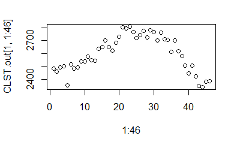

```r
  plot(1:46, CLST.out[1,1:46])
```

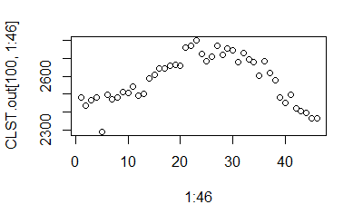

```r
  plot(1:46, CLST.out[100,1:46])
```

```r
  write.dbf(CLST.out, file = paste0("D:/OneDrive/work/research/CHaMP/CHaMP_data/Feather/mainstem/2015/LST15_FR_interp.dbf"))
```

This part calculates the zonal mean of the daily LST for each RCA

```r
out_Preds <- read.dbf("D:/OneDrive/work/research/CHaMP/CHaMP_data/Feather/mainstem/2015/LST15_FR_interp.dbf")


  weights <- read.csv("D:/OneDrive/work/research/CHaMP/CHaMP_data/Feather/FR_rca_area_wgts.csv")
  weights[weights$area_wgt<0.01, "area_wgt"] = 0.01
  colnames(weights)[1] <- "RCAID"
  rcas <- unique(unlist(weights$RCAID))
  rca_zonal <- matrix(ncol=46, nrow=length(rcas))


  l <- 1

  for(i in rcas)
    {
      pixels <- weights[weights$RCAID == i, "GRIDCODE"]
      wgts <- weights[weights$RCAID == i, "area_wgt"]

      for (j in 1:46)
      {
        daily <- out_Preds[out_Preds$PointID %in% pixels, j]
        zonal_mn <- weighted.mean(daily, wgts, na.rm = TRUE)
        rca_zonal[l,j] <- zonal_mn
      }
      l <- l+1
    }


  colnames(rca_zonal)[1:46] <- colnames(out_Preds)[1:46]
  rca_zonal <- as.data.frame(rca_zonal)
  rca_zonal$RCAID <- rcas
```

Plot to look

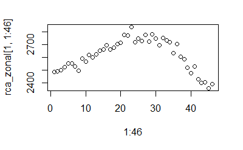

```r
  plot(1:46, rca_zonal[1,1:46])
```

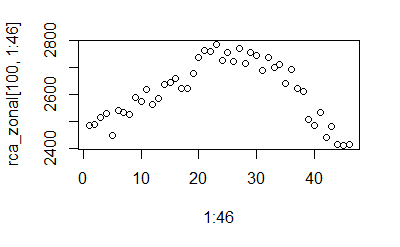

```r
  plot(1:46, rca_zonal[100,1:46])
```

```r
  write.dbf(rca_zonal, file = paste0("D:/OneDrive/work/research/CHaMP/CHaMP_data/Feather/mainstem/2015/LST15_FR_RCA.dbf"))
```

Discharge data formatting

```r
  Dv.in <- read.csv("D:/OneDrive/work/research/CHaMP/CHaMP_Data/Feather/Mainstem/2015/FR_dv_data_2015_main.csv", stringsAsFactors = FALSE)

  dates <- matrix(nrow=365, ncol=1)
  dates[,1] <- 1:365
  colnames(dates) <- c("Days")

  SiteID <- unique(Dv.in$site_no)
  SiteID <- as.matrix(SiteID)
  Dv.8Day.out <- data.frame (mup = NULL)

  for (i in SiteID)
    {
      Dv.site <- Dv.in[Dv.in$site_no == i,]
      full.year <- merge(dates, Dv.site, by.x = "Days", by.y = "JulDay", all.x = TRUE)
      eightday <- rollapply(full.year$Dv, width = 8, FUN = mean, na.rm = T, fill = NA, align = c("left"))
      eightday <- as.matrix(eightday)
      full.year$Dv8D<- eightday
      full.year$Dv8D[361] <- mean(full.year$Dv[361:365 ])
      Dv.8Day.out <- rbind(Dv.8Day.out, full.year)

    }

  ind <- apply(Dv.8Day.out, 1, function(x) !any(is.na(x)))
  Dv.8Day.out <- Dv.8Day.out[ind,]
write.csv(Dv.8Day.out, paste0("D:/OneDrive/work/research/CHaMP/CHaMP_data/Feather/mainstem/2015/FR_2015_Dv_8Day_main", ".csv"), row.names = FALSE)
```

Model building. Builds complete (no NA) dataset with discharge, elevation, LST, JulDay. Splits data into spring and fall with the max temp of the year.

```r
  Log.in <- read.csv("D:/OneDrive/work/research/CHaMP/CHaMP_data/Feather/mainstem/2015/FR_logger_8D_2015_mainstem.csv", stringsAsFactors = FALSE)

  ID.in <- read.csv("D:/OneDrive/work/research/CHaMP/GIS/coverages/Feather_River/FR_sites_rca_2015_main.csv", stringsAsFactors = FALSE)

  LST.in <- read.dbf(paste0("D:/OneDrive/work/research/CHaMP/CHaMP_data/Feather/mainstem/2015/LST15_FR_RCA.dbf"))
  colnames(LST.in)<-gsub("X", "", colnames(LST.in))
  newnamesnum <- as.numeric(colnames(LST.in)[1:46]);
  Dv.in <- read.csv("D:/OneDrive/work/research/CHaMP/CHaMP_data/Feather/mainstem/2015/FR_2015_Dv_8Day_main.csv", stringsAsFactors = FALSE)

  Dv.in <- Dv.in[,c("Dv8D", "Days")]

  LST.Log.out <- data.frame (mup = NULL)
  SiteID <- unique(Log.in$SiteName)

  for (i in SiteID)
    {
      Log.site <- Log.in[Log.in$SiteName  == i,]
      Log.site <- as.data.frame(Log.site)

      RCAID <- ID.in$RCAID[ID.in$SiteName == i]

      Elev <- ID.in$Elev[ID.in$SiteName == i]

      LST.site <- matrix(ncol=3, nrow=46)
      LST.site[,1] <- as.numeric(unlist(colnames(LST.in)[1:46]))
      LST.site[,2] <- unlist(LST.in[LST.in$RCAID == RCAID, 1:46])
      LST.site <- data.frame(LST.site)
      colnames(LST.site) <- c("JulDay", "LST", "Elev")
      LST.site[3] <- Elev


      LST.Log.site <- merge(LST.site, Log.site, by = "JulDay", all.x=TRUE, all.y = FALSE)
      LST.Log.site <- merge(LST.Log.site, Dv.in, by.x = "JulDay", by.y = "Days", all.x=TRUE, all.y+FALSE)

      LST.Log.out <- rbind(LST.Log.out, LST.Log.site)

    }

  Dv <- unlist(LST.Log.site$Dv8D)

  ind <- apply(LST.Log.out, 1, function(x) !any(is.na(x)))
  NoNA.xyz <- LST.Log.out[ind,]

  NoNA.xyz <- NoNA.xyz[,c(dataVar, "LST", "JulDay", "Elev", "Dv8D", "SiteName")]
  colnames(NoNA.xyz) <- c("y", "x", "z", "e", "d", "SiteName")

  write.csv(x=NoNA.xyz, file= paste0(basin, "_mainstem", yearPath, "_8Day_", var, "_model_data_main.csv"), row.names = FALSE)
  NoNA.xyz <- read.csv(paste0(basin, "_mainstem", yearPath, "_8Day_", var, "_model_data_main.csv"), stringsAsFactors = FALSE)

  NoNA.xyz <- orderBy(~z, NoNA.xyz)
  maxrow <- which.max(NoNA.xyz$y)
  data.sp <- NoNA.xyz[1:(maxrow-1),]
  rownames(data.sp) <- 1:dim(data.sp)[1]
  data.fall <- NoNA.xyz[maxrow:nrow(NoNA.xyz),]
  rownames(data.fall) <- 1:dim(data.fall)[1]
```

Correlation matrix

```r
cor.full <- NoNA.xyz[1:5]
cor(cor.full)
```

```
           y          x           z           e           d
y  1.0000000  0.8567826 -0.52206270 -0.39250190  0.31166948
x  0.8567826  1.0000000 -0.69577877 -0.28639093  0.41773817
z -0.5220627 -0.6957788  1.00000000  0.04384867 -0.55855787
e -0.3925019 -0.2863909  0.04384867  1.00000000 -0.07462782
d  0.3116695  0.4177382 -0.55855787 -0.07462782  1.00000000
```

plot the data

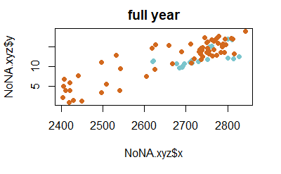

```r
  {plot(NoNA.xyz$x, NoNA.xyz$y, main = "full year")
  points(data.sp$x, data.sp$y, pch=16, col="cadetblue3")
  points(data.fall$x, data.fall$y, pch=16, col="chocolate")}
```

```r
NA
```

#### Full year models

```r
  y <- NoNA.xyz$y
  x <- NoNA.xyz$x
  z <- NoNA.xyz$z
  e <- NoNA.xyz$e
  d <- NoNA.xyz$d
  m <- NoNA.xyz$m

  mod <- lm(y ~ x + I(x^2) + z+ e)
  sum_mod <- summary(mod)
  sum_mod
```

```
Call:
lm(formula = y ~ x + I(x^2) + z + e)

Residuals:
    Min      1Q  Median      3Q     Max
-4.3645 -1.4388 -0.3758  1.6137  4.7684

Coefficients:
              Estimate Std. Error t value Pr(>|t|)
(Intercept) -2.361e+02  1.270e+02  -1.859   0.0669 .
x            1.577e-01  9.654e-02   1.634   0.1065
I(x^2)      -2.423e-05  1.836e-05  -1.319   0.1911
z            7.657e-03  4.954e-03   1.546   0.1264
e           -1.702e-03  7.045e-04  -2.415   0.0181 *
---
Signif. codes:  0 *** 0.001 ** 0.01 * 0.05 . 0.1   1

Residual standard error: 2.136 on 76 degrees of freedom
Multiple R-squared:  0.7679,    Adjusted R-squared:  0.7557
F-statistic: 62.86 on 4 and 76 DF,  p-value: < 2.2e-16
```

Model prediction

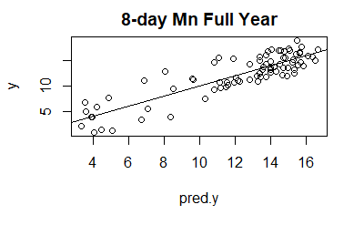

```r
  pred.y <- predict(mod)
  {plot(pred.y, y, main = paste0("8-day ", var, " Full Year"))
  abline(0,1)}
```

Model diagnostics

```r
  post_mod <- summary(lm(y ~ pred.y))
  gvmodel <- gvlma(mod)
  summary(gvmodel)
```

```
Call:
lm(formula = y ~ x + I(x^2) + z + e)

Residuals:
    Min      1Q  Median      3Q     Max
-4.3645 -1.4388 -0.3758  1.6137  4.7684

Coefficients:
              Estimate Std. Error t value Pr(>|t|)
(Intercept) -2.361e+02  1.270e+02  -1.859   0.0669 .
x            1.577e-01  9.654e-02   1.634   0.1065
I(x^2)      -2.423e-05  1.836e-05  -1.319   0.1911
z            7.657e-03  4.954e-03   1.546   0.1264
e           -1.702e-03  7.045e-04  -2.415   0.0181 *
---
Signif. codes:  0 *** 0.001 ** 0.01 * 0.05 . 0.1   1

Residual standard error: 2.136 on 76 degrees of freedom
Multiple R-squared:  0.7679,    Adjusted R-squared:  0.7557
F-statistic: 62.86 on 4 and 76 DF,  p-value: < 2.2e-16


ASSESSMENT OF THE LINEAR MODEL ASSUMPTIONS
USING THE GLOBAL TEST ON 4 DEGREES-OF-FREEDOM:
Level of Significance =  0.05

Call:
 gvlma(x = mod)

                    Value p-value                   Decision
Global Stat        11.086 0.02561 Assumptions NOT satisfied!
Skewness            1.271 0.25966    Assumptions acceptable.
Kurtosis            1.274 0.25906    Assumptions acceptable.
Link Function       2.880 0.08968    Assumptions acceptable.
Heteroscedasticity  5.661 0.01734 Assumptions NOT satisfied!
```

```r
  outlierTest(mod)
```

```
No Studentized residuals with Bonferonni p < 0.05
Largest |rstudent|:
   rstudent unadjusted p-value Bonferonni p
66 2.354774           0.021152           NA
```

recheck assumptions

```r
  gvmodel <- gvlma(mod)
  summary(gvmodel)
```

```
Call:
lm(formula = y ~ x + I(x^2) + z + e)

Residuals:
    Min      1Q  Median      3Q     Max
-4.3645 -1.4388 -0.3758  1.6137  4.7684

Coefficients:
              Estimate Std. Error t value Pr(>|t|)
(Intercept) -2.361e+02  1.270e+02  -1.859   0.0669 .
x            1.577e-01  9.654e-02   1.634   0.1065
I(x^2)      -2.423e-05  1.836e-05  -1.319   0.1911
z            7.657e-03  4.954e-03   1.546   0.1264
e           -1.702e-03  7.045e-04  -2.415   0.0181 *
---
Signif. codes:  0 *** 0.001 ** 0.01 * 0.05 . 0.1   1

Residual standard error: 2.136 on 76 degrees of freedom
Multiple R-squared:  0.7679,    Adjusted R-squared:  0.7557
F-statistic: 62.86 on 4 and 76 DF,  p-value: < 2.2e-16


ASSESSMENT OF THE LINEAR MODEL ASSUMPTIONS
USING THE GLOBAL TEST ON 4 DEGREES-OF-FREEDOM:
Level of Significance =  0.05

Call:
 gvlma(x = mod)

                    Value p-value                   Decision
Global Stat        11.086 0.02561 Assumptions NOT satisfied!
Skewness            1.271 0.25966    Assumptions acceptable.
Kurtosis            1.274 0.25906    Assumptions acceptable.
Link Function       2.880 0.08968    Assumptions acceptable.
Heteroscedasticity  5.661 0.01734 Assumptions NOT satisfied!
```

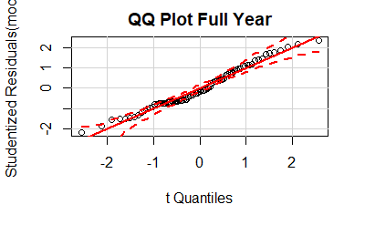

```r
  qqPlot(mod, main="QQ Plot Full Year")
```

Assumptions:

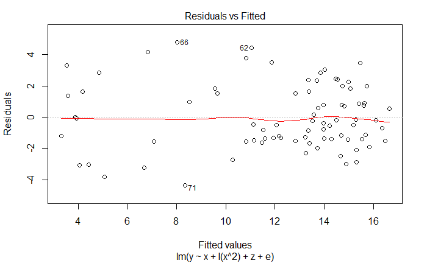

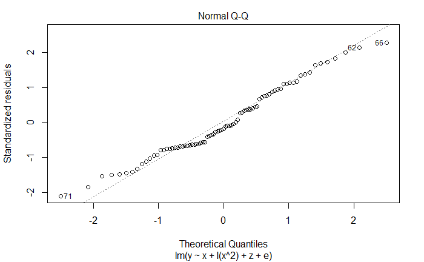

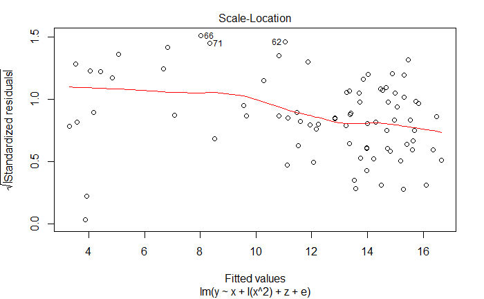

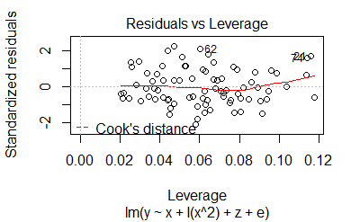

```r
plot(mod)
```

```
Suggested power transformation:  1.431817
```

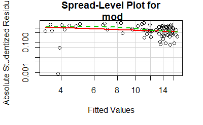

```r
  spreadLevelPlot(mod)
```

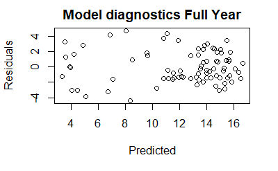

```r
  plot(pred.y, mod$residuals, main="Model diagnostics Full Year", xlab="Predicted", ylab="Residuals")
```

```r
  pressstat_sum <- PRESS(mod, verbose = "FALSE")
  RMSEP <- sqrt(mean((pressstat_sum$residuals)^2))

  library(pls)
  mod2 <- plsr(y ~ x + I(x^2) + z + e, validation = "LOO")
  p2 <- R2(mod2)
  detach("package:pls", unload=TRUE)

  coeffs <- as.matrix(coefficients(sum_mod))

  pred.out <- matrix(nrow=length(pred.y), ncol=5)
  pred.out[,1] <- y
  pred.out[,2] <- pred.y
  pred.out[,3] <- z
  pred.out[,4] <- "full year"
  pred.out[,5] <- yearPath
  colnames(pred.out) <- c("Y", "PredY", "JulDay", "Season", "Year")
  write.table (x=pred.out,append=T,row.names=F,file=paste0("jk_pred_v_y_", var, "_", basin, "_mainstem", yearPath, "_full_year.csv"),sep = ",", col.names=F)
```

```r
  fit <- lm(y~ pred.y)

  summary(fit)
```

[output not shown]

Output tables formatting for coeffs and metrics

```r
  coeffs_out <- data.frame(Int=numeric(2), bLST=numeric(2), bLST2=numeric(2), bJul=numeric(2), bElev=numeric(2), bD=numeric(2))
  metrics_out <- data.frame(r2=numeric(2), RMSE=numeric(2), p2=numeric(2), RMSEP=numeric(2), N_Sites=numeric(2), N=numeric(2))
  rownames(metrics_out) <- c("Spring", "Fall")
  rownames(coeffs_out) <- c("Spring", "Fall")
  coeffs_out[1,1] <- coeffs[1,1]
  coeffs_out[1,2] <- coeffs[2,1]
  coeffs_out[1,3] <- coeffs[3,1]
  coeffs_out[1,4] <- coeffs[4,1]
  coeffs_out[1,5] <- coeffs[5,1]


  metrics_out[1,1] <- sum_mod$adj.r.squared
  metrics_out[1,2] <- sum_mod$sigma
  metrics_out[1,3] <- p2$val[5]
  metrics_out[1,4] <- RMSEP
  metrics_out[1,5] <- length(unique(NoNA.xyz$SiteName))
  metrics_out[1,6] <- length(y)

  coeffs_out[2,1] <- coeffs[1,1]
  coeffs_out[2,2] <- coeffs[2,1]
  coeffs_out[2,3] <- coeffs[3,1]
  coeffs_out[2,4] <- coeffs[4,1]
  coeffs_out[2,5] <- coeffs[5,1]

  metrics_out[2,1] <- sum_mod$adj.r.squared
  metrics_out[2,2] <- post_mod$sigma
  metrics_out[2,3] <- p2$val[5]
  metrics_out[2,4] <- RMSEP
  metrics_out[2,5] <- length(unique(NoNA.xyz$SiteName))
  metrics_out[2,6] <- length(y)


  write.table(x=coeffs_out, append=F,row.names=T, file = paste0("All_data_", basin, "_mainstem", yearPath, "_mod_coeffs_", var, ".csv"), sep = ",", col.names=T)

  write.table(x=metrics_out, append=F,row.names=T, file = paste0("All_data_", basin, "_mainstem", yearPath, "_mod_metrics_", var, ".csv"), sep = ",", col.names=T)
```

#### Spring/Fall models

Spring data model

```r
  coeffs_out <- data.frame(Int=numeric(2), bLST=numeric(2), bLST2=numeric(2), bJul=numeric(2), bElev=numeric(2), bD=numeric(2), bDJul=numeric(2), bJulm=numeric(2), bm=numeric(2))
  metrics_out <- data.frame(r2=numeric(2), RMSE=numeric(2), p2=numeric(2), RMSEP=numeric(2), N_Sites=numeric(2), N=numeric(2))
  rownames(metrics_out) <- c("Spring", "Fall")
  rownames(coeffs_out) <- c("Spring", "Fall")
```

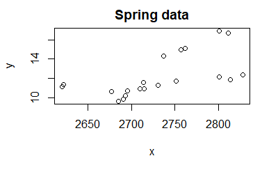

```r
  y <- data.sp$y
  x <- data.sp$x
  z <- data.sp$z
  e <- data.sp$e
  d <- data.sp$d
  m <- data.sp$m
  plot(x, y, main="Spring data")
```

```r
  mod <- lm(y ~ x + I(x^2) + z + e)
  sum_mod <- summary(mod)
  sum_mod
```

```
Call:
lm(formula = y ~ x + I(x^2) + z + e)

Residuals:
    Min      1Q  Median      3Q     Max
-2.0824 -0.9802  0.0843  0.5359  3.2381

Coefficients:
              Estimate Std. Error t value Pr(>|t|)
(Intercept) -9.051e+02  9.571e+02  -0.946   0.3593
x            6.642e-01  7.050e-01   0.942   0.3611
I(x^2)      -1.218e-04  1.304e-04  -0.934   0.3652
z            7.918e-02  3.546e-02   2.233   0.0412 *
e            6.163e-04  2.055e-03   0.300   0.7684
---
Signif. codes:  0 *** 0.001 ** 0.01 * 0.05 . 0.1   1

Residual standard error: 1.627 on 15 degrees of freedom
Multiple R-squared:  0.5607,    Adjusted R-squared:  0.4435
F-statistic: 4.786 on 4 and 15 DF,  p-value: 0.0109
```

#### Model diagnostics

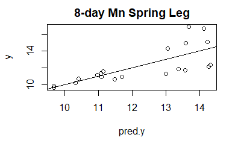

```r
  pred.y <- predict(mod)
  pred.y[pred.y < -0.5] = -0.5
  {plot(pred.y, y, main = paste0("8-day ", var, " Spring Leg"))
  abline(0,1)}
```

Test assumption of linear model

```r
  post_mod <- summary(lm(y ~ pred.y))
  gvmodel <- gvlma(mod)
  summary(gvmodel)
```

```
Call:
lm(formula = y ~ x + I(x^2) + z + e)

Residuals:
    Min      1Q  Median      3Q     Max
-2.0824 -0.9802  0.0843  0.5359  3.2381

Coefficients:
              Estimate Std. Error t value Pr(>|t|)
(Intercept) -9.051e+02  9.571e+02  -0.946   0.3593
x            6.642e-01  7.050e-01   0.942   0.3611
I(x^2)      -1.218e-04  1.304e-04  -0.934   0.3652
z            7.918e-02  3.546e-02   2.233   0.0412 *
e            6.163e-04  2.055e-03   0.300   0.7684
---
Signif. codes:  0 *** 0.001 ** 0.01 * 0.05 . 0.1   1

Residual standard error: 1.627 on 15 degrees of freedom
Multiple R-squared:  0.5607,    Adjusted R-squared:  0.4435
F-statistic: 4.786 on 4 and 15 DF,  p-value: 0.0109


ASSESSMENT OF THE LINEAR MODEL ASSUMPTIONS
USING THE GLOBAL TEST ON 4 DEGREES-OF-FREEDOM:
Level of Significance =  0.05

Call:
 gvlma(x = mod)

                     Value  p-value                   Decision
Global Stat        8.54054 0.073668    Assumptions acceptable.
Skewness           0.72201 0.395484    Assumptions acceptable.
Kurtosis           0.03812 0.845197    Assumptions acceptable.
Link Function      0.05403 0.816201    Assumptions acceptable.
Heteroscedasticity 7.72638 0.005442 Assumptions NOT satisfied!
```

check for outliers

```r
  outlierTest(mod)
```

```
No Studentized residuals with Bonferonni p < 0.05
Largest |rstudent|:
   rstudent unadjusted p-value Bonferonni p
19 3.644015          0.0026562     0.053124
```

recheck assumptions

```r
  gvmodel <- gvlma(mod)
  summary(gvmodel)
```

```
Call:
lm(formula = y ~ x + I(x^2) + z + e)

Residuals:
    Min      1Q  Median      3Q     Max
-2.0824 -0.9802  0.0843  0.5359  3.2381

Coefficients:
              Estimate Std. Error t value Pr(>|t|)
(Intercept) -9.051e+02  9.571e+02  -0.946   0.3593
x            6.642e-01  7.050e-01   0.942   0.3611
I(x^2)      -1.218e-04  1.304e-04  -0.934   0.3652
z            7.918e-02  3.546e-02   2.233   0.0412 *
e            6.163e-04  2.055e-03   0.300   0.7684
---
Signif. codes:  0 *** 0.001 ** 0.01 * 0.05 . 0.1   1

Residual standard error: 1.627 on 15 degrees of freedom
Multiple R-squared:  0.5607,    Adjusted R-squared:  0.4435
F-statistic: 4.786 on 4 and 15 DF,  p-value: 0.0109


ASSESSMENT OF THE LINEAR MODEL ASSUMPTIONS
USING THE GLOBAL TEST ON 4 DEGREES-OF-FREEDOM:
Level of Significance =  0.05

Call:
 gvlma(x = mod)

                     Value  p-value                   Decision
Global Stat        8.54054 0.073668    Assumptions acceptable.
Skewness           0.72201 0.395484    Assumptions acceptable.
Kurtosis           0.03812 0.845197    Assumptions acceptable.
Link Function      0.05403 0.816201    Assumptions acceptable.
Heteroscedasticity 7.72638 0.005442 Assumptions NOT satisfied!
```

more tests: qqplot

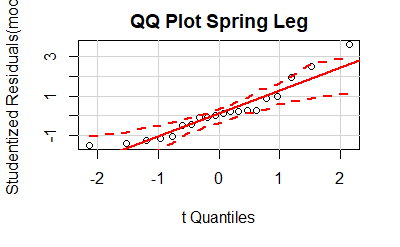

```r
  qqPlot(mod, main="QQ Plot Spring Leg")
```

format the data for prediction output

```r
  coeffs <- as.matrix(coefficients(mod))
  pred.y <- predict(mod)

  pred.y[pred.y < -0.5] = -0.5
```

Look at the residuals

```
Suggested power transformation:  -8.104711
```

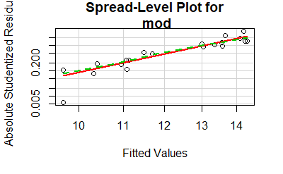

```r
  spreadLevelPlot(mod)
```

LOO PRESS stats

```r
  pressstat_sum <- PRESS(sum_mod, verbose = "FALSE")
  RMSEP <- sqrt(mean((pressstat_sum$residuals)^2))

  library(pls)
  mod2 <- plsr(y ~ x + I(x^2) + z + e, validation = "LOO")
  p2 <- R2(mod2)
  detach("package:pls", unload=TRUE)
```

write out predicted, coeffs, & metrics

```r
  pred.out <- matrix(nrow=length(pred.y), ncol=5)
  pred.out[,1] <- y
  pred.out[,2] <- pred.y
  pred.out[,3] <- z
  pred.out[,4] <- "Spring"
  pred.out[,5] <- yearPath
  colnames(pred.out) <- c("Y", "PredY", "JulDay", "Season", "Year")
  write.table (x=pred.out,append=F,row.names=F,file=paste0("jk_pred_v_y_", var, "_", basin, "_mainstem", yearPath, "_sp_fall.csv"),sep = ",", col.names=F)

  coeffs_out[1,1] <- coeffs[1,1]
  coeffs_out[1,2] <- coeffs[2,1]
  coeffs_out[1,3] <- coeffs[3,1]
  coeffs_out[1,4] <- coeffs[4,1]
  coeffs_out[1,5] <- coeffs[5,1]
  metrics_out[1,1] <- sum_mod$adj.r.squared
  metrics_out[1,2] <- sum_mod$sigma
  metrics_out[1,3] <- p2$val[5]
  metrics_out[1,4] <- RMSEP
  metrics_out[1,5] <- length(unique(data.sp$SiteName))
  metrics_out[1,6] <- length(y)
```

Fall data model

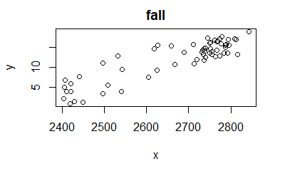

```r
  y <- data.fall$y
  x <- data.fall$x
  z <- data.fall$z
  e <- data.fall$e
  d <- data.fall$d
  m <- data.fall$m

  plot(x, y, main="fall")
```

```r
  mod <- lm(y ~ x + I(x^2) + z + e)
  sum_mod <- summary(mod)
  sum_mod
```

```
Call:
lm(formula = y ~ x + I(x^2) + z + e)

Residuals:
   Min     1Q Median     3Q    Max
-4.178 -1.401 -0.147  1.375  4.432

Coefficients:
              Estimate Std. Error t value Pr(>|t|)
(Intercept) -2.795e+02  1.477e+02  -1.892   0.0636 .
x            2.085e-01  1.152e-01   1.810   0.0757 .
I(x^2)      -3.595e-05  2.232e-05  -1.611   0.1129
z           -2.489e-02  1.322e-02  -1.882   0.0650 .
e           -1.474e-03  7.507e-04  -1.963   0.0546 .
---
Signif. codes:  0 *** 0.001 ** 0.01 * 0.05 . 0.1   1

Residual standard error: 2.137 on 56 degrees of freedom
Multiple R-squared:  0.8177,    Adjusted R-squared:  0.8046
F-statistic: 62.78 on 4 and 56 DF,  p-value: < 2.2e-16
```

#### Model Diagnostics

plot predicted v observed

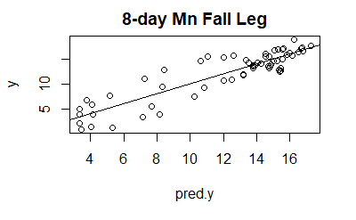

```r
  pred.y <- predict(mod)
  pred.y[pred.y < -0.5] = -0.5
  {plot(pred.y, y, main = paste0("8-day ", var, " Fall Leg"))
  abline(0,1)}
```

Tests of assumptions of linear model

```r
  gvmodel <- gvlma(mod)
  summary(gvmodel)
```

```
Call:
lm(formula = y ~ x + I(x^2) + z + e)

Residuals:
   Min     1Q Median     3Q    Max
-4.178 -1.401 -0.147  1.375  4.432

Coefficients:
              Estimate Std. Error t value Pr(>|t|)
(Intercept) -2.795e+02  1.477e+02  -1.892   0.0636 .
x            2.085e-01  1.152e-01   1.810   0.0757 .
I(x^2)      -3.595e-05  2.232e-05  -1.611   0.1129
z           -2.489e-02  1.322e-02  -1.882   0.0650 .
e           -1.474e-03  7.507e-04  -1.963   0.0546 .
---
Signif. codes:  0 *** 0.001 ** 0.01 * 0.05 . 0.1   1

Residual standard error: 2.137 on 56 degrees of freedom
Multiple R-squared:  0.8177,    Adjusted R-squared:  0.8046
F-statistic: 62.78 on 4 and 56 DF,  p-value: < 2.2e-16


ASSESSMENT OF THE LINEAR MODEL ASSUMPTIONS
USING THE GLOBAL TEST ON 4 DEGREES-OF-FREEDOM:
Level of Significance =  0.05

Call:
 gvlma(x = mod)

                    Value p-value                   Decision
Global Stat        9.0420 0.06006    Assumptions acceptable.
Skewness           0.3403 0.55965    Assumptions acceptable.
Kurtosis           0.3960 0.52916    Assumptions acceptable.
Link Function      2.1081 0.14653    Assumptions acceptable.
Heteroscedasticity 6.1976 0.01279 Assumptions NOT satisfied!
```

check for outliers

```r
  outlierTest(mod)
```

```
No Studentized residuals with Bonferonni p < 0.05
Largest |rstudent|:
   rstudent unadjusted p-value Bonferonni p
42 2.221727           0.030435           NA
```

recheck assumptions

```r
  gvmodel <- gvlma(mod)
  summary(gvmodel)
```

```
Call:
lm(formula = y ~ x + I(x^2) + z + e)

Residuals:
   Min     1Q Median     3Q    Max
-4.178 -1.401 -0.147  1.375  4.432

Coefficients:
              Estimate Std. Error t value Pr(>|t|)
(Intercept) -2.795e+02  1.477e+02  -1.892   0.0636 .
x            2.085e-01  1.152e-01   1.810   0.0757 .
I(x^2)      -3.595e-05  2.232e-05  -1.611   0.1129
z           -2.489e-02  1.322e-02  -1.882   0.0650 .
e           -1.474e-03  7.507e-04  -1.963   0.0546 .
---
Signif. codes:  0 *** 0.001 ** 0.01 * 0.05 . 0.1   1

Residual standard error: 2.137 on 56 degrees of freedom
Multiple R-squared:  0.8177,    Adjusted R-squared:  0.8046
F-statistic: 62.78 on 4 and 56 DF,  p-value: < 2.2e-16


ASSESSMENT OF THE LINEAR MODEL ASSUMPTIONS
USING THE GLOBAL TEST ON 4 DEGREES-OF-FREEDOM:
Level of Significance =  0.05

Call:
 gvlma(x = mod)

                    Value p-value                   Decision
Global Stat        9.0420 0.06006    Assumptions acceptable.
Skewness           0.3403 0.55965    Assumptions acceptable.
Kurtosis           0.3960 0.52916    Assumptions acceptable.
Link Function      2.1081 0.14653    Assumptions acceptable.
Heteroscedasticity 6.1976 0.01279 Assumptions NOT satisfied!
```

plot model diagnostics

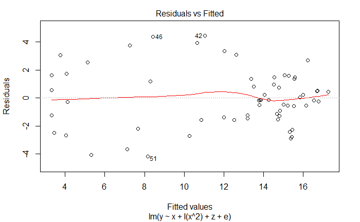

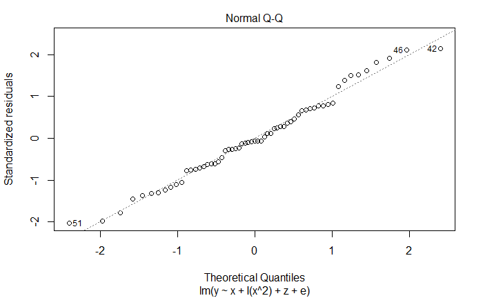

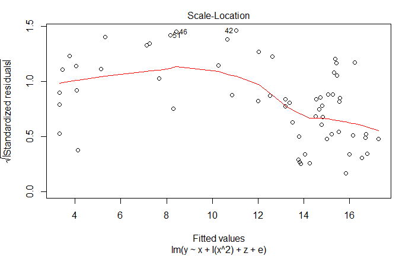

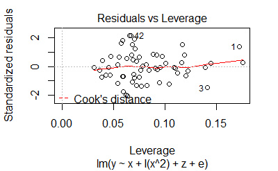

```r
  plot(mod)
```

more diagonstics: qqplot

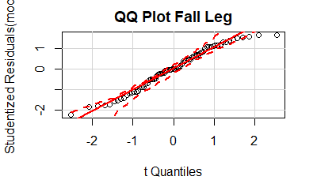

```r
  qqPlot(mod, main="QQ Plot Fall Leg")
```

format data for prediction output

```r
  coeffs <- as.matrix(coefficients(mod))
  post_mod <- summary(lm(y ~ pred.y))
```

LOO PRESS stats

```r
  pressstat_sum <- PRESS(sum_mod, verbose = "FALSE")
  RMSEP <- sqrt(mean((pressstat_sum$residuals)^2))

  library(pls)
  mod2 <- plsr(y ~ x + I(x^2) + z+ e, validation = "LOO")
  p2 <- R2(mod2)
  detach("package:pls", unload=TRUE)
```

write out predicted, coeffs, & metrics

```r
  pred.out <- matrix(nrow=length(pred.y), ncol=5)
  pred.out[,1] <- y
  pred.out[,2] <- pred.y
  pred.out[,3] <- z
  pred.out[,4] <- "fall"
  pred.out[,5] <- yearPath

  write.table (x=pred.out,append=T,row.names=F,file=paste0("jk_pred_v_y_", var, "_", basin, "_mainstem", yearPath, "_sp_fall.csv"),sep = ",", col.names=F)

  coeffs_out[2,1] <- coeffs[1,1]
  coeffs_out[2,2] <- coeffs[2,1]
  coeffs_out[2,3] <- coeffs[3,1]
  coeffs_out[2,4] <- coeffs[4,1]
  coeffs_out[2,5] <- coeffs[5,1]

  metrics_out[2,1] <- sum_mod$adj.r.squared
  metrics_out[2,2] <- post_mod$sigma
  metrics_out[2,3] <- p2$val[5]
  metrics_out[2,4] <- RMSEP
  metrics_out[2,5] <- length(unique(data.fall$SiteName))
  metrics_out[2,6] <- length(y)

  write.table(x=coeffs_out, append=F,row.names=T, file = paste0("All_data_", basin, "_mainstem", yearPath, "_mod_coeffs_", var, ".csv"), sep = ",", col.names=T)

  write.table(x=metrics_out, append=F,row.names=T, file = paste0("All_data_", basin, "_mainstem", yearPath, "_mod_metrics_", var, ".csv"), sep = ",", col.names=T)
```

plot the full year of predicted v observed

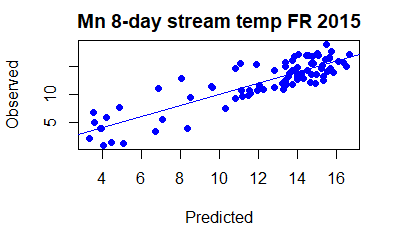

```r
  pred.y <- read.csv(paste0("jk_pred_v_y_", var, "_", basin, "_mainstem", yearPath, "_full_year.csv"), stringsAsFactors = FALSE, header = FALSE)
  colnames(pred.y) <- c("Y", "PredY", "JulDay", "Season", "Year")

  {plot(pred.y$PredY, pred.y$Y, pch=16, col="blue", main=paste0(var, " 8-day stream temp ", basin, " ", yearPath), xlab="Predicted", ylab="Observed")
  abline(0,1)
  abline(lm(pred.y$Y~ pred.y$PredY), col="blue")}
```

full year fit metrics

```r
  fit <- lm(pred.y$Y~ pred.y$PredY)

  summary(fit)
```

```
Call:
lm(formula = pred.y$Y ~ pred.y$PredY)

Residuals:
    Min      1Q  Median      3Q     Max
-4.3645 -1.4388 -0.3758  1.6137  4.7684

Coefficients:
              Estimate Std. Error t value Pr(>|t|)
(Intercept)  9.825e-14  5.509e-01    0.00        1
pred.y$PredY 1.000e+00  4.346e-02   23.01   <2e-16 ***
---
Signif. codes:  0 *** 0.001 ** 0.01 * 0.05 . 0.1   1

Residual standard error: 2.081 on 160 degrees of freedom
Multiple R-squared:  0.7679,    Adjusted R-squared:  0.7665
F-statistic: 529.4 on 1 and 160 DF,  p-value: < 2.2e-16
```

This part applies the model coefficients to the LST to generate 8-day temp estimates

```r
  elev.in <- read.csv(paste0("D:/OneDrive/work/research/CHaMP/CHaMP_data/Feather/FR_rca_elev.csv"), stringsAsFactors = F)

  LST.in <- read.dbf(paste0("D:/OneDrive/work/research/CHaMP/CHaMP_data/Feather/mainstem/2015/LST15_FR_RCA.dbf"))

  colnames(LST.in)<-gsub("X", "", colnames(LST.in))

  newnamesnum <- as.numeric(colnames(LST.in)[1:46])

  LST.elev <- merge(LST.in, elev.in, by = "RCAID")

  coeffs.in <- read.csv(paste0("All_data_", basin, "_mainstem", yearPath, "_mod_coeffs_", var, ".csv"), stringsAsFactors=FALSE)
  LogPred.out <- LST.elev[,c(2:47,48,1)]
  LogPred.out[,1:46] <- 0
  rcas <- unique(LST.elev$RCAID)
  LST.sum <- LST.elev[,c(2:47, 48,1)]

   for (i in 1:length(rcas))
      {
        x <- unlist(LST.sum[i,])
        maxrow <- 29 #as.numeric(which.max(x[1:46]))
        midrow <- maxrow - 1
        day <- as.numeric(colnames(LST.sum)[maxrow])

        j <- 1
        for (l in 1:midrow)
        {x[l] <- x[l] * coeffs.in$bLST[1] + j * coeffs.in$bJul[1] +  x[47] * coeffs.in$bElev[1] + x[l]^2 * coeffs.in$bLST2[1] + coeffs.in$Int[1]
        j <- j + 8}
        k <- day
        for (l in maxrow:46)
        {x[l] <- x[l] * coeffs.in$bLST[2] + k * coeffs.in$bJul[2] +  x[47] * coeffs.in$bElev[2] + x[l]^2 * coeffs.in$bLST2[2] + coeffs.in$Int[2]
        k <- k + 8}
        if (maxrow > 3)
        {
          x[(midrow)] <- NA
          fill <- na.spline(x[1:46],)
          x[(maxrow-3):(maxrow+3)] <- fill[(maxrow-3):(maxrow+3)]
        }
        LogPred.out[i,1:46] <- x [1:46]
      }


  LogPred.out <- as.data.frame(LogPred.out)

  LogPred.out$Basin_RCA <- paste0(basin, "_mainstem", LogPred.out$RCAID)
  namesnum <- as.numeric(colnames(LogPred.out[1:46]))
  varName <- paste0("T", var, yrPath)
  names.out <- sprintf("%s_%03d", varName, namesnum)
  colnames(LogPred.out)[1:46] <- names.out[1:46]
  LogPred.out[LogPred.out < -0.5] = -0.5

  write.dbf(LogPred.out, file = paste0("predt", yearPath, "_", basin, "mainstem_8D_", var, ".dbf"))
```

Plot orig data

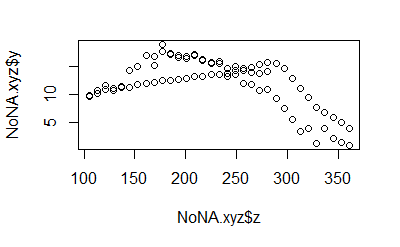

```r
  plot(NoNA.xyz$z, NoNA.xyz$y)
```

Plot some reaches to take a peek

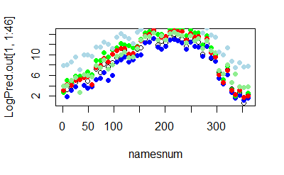

```r
  {plot(namesnum, LogPred.out[1,1:46])
  points(namesnum, LogPred.out[10, 1:46], pch=16, col="blue")
  points(namesnum, LogPred.out[150, 1:46], pch=16, col="green")
  points(namesnum, LogPred.out[200, 1:46], pch=16, col="red")
  points(namesnum, LogPred.out[100, 1:46], pch=16, col="lightgreen")
  points(namesnum, LogPred.out[80, 1:46], pch=16, col="lightblue")}
```

```r
NA
```

This parts formats the error by day/site info

```r
  Log.in <- read.csv(paste0("D:/OneDrive/work/research/CHaMP/CHaMP_data/Feather/mainstem/2015/FR_logger_8D_2015_mainstem.csv"), stringsAsFactors = FALSE)

  ID.in <- read.csv(paste0("D:/OneDrive/work/research/CHaMP/GIS/coverages/Feather_River/FR_sites_rca_2015_main.csv"), stringsAsFactors = FALSE)


  Pred.in <- read.dbf(paste0("predt", yearPath, "_", basin, "mainstem_8D_", var, ".dbf"))
  colnames(Pred.in)<-gsub(varName, "", colnames(Pred.in))
  colnames(Pred.in)<-gsub("_", "", colnames(Pred.in))
  newnamesnum <- as.numeric(colnames(Pred.in)[1:46]);

  Pred.Log.out <- data.frame (mup = NULL)
  SiteID <- unique(Log.in$SiteName)
    for (i in SiteID)
      {
        Log.site <- Log.in[Log.in$SiteName  == i,]
        Log.site <- as.data.frame(Log.site)


        RCAID <- ID.in$RCAID[ID.in$SiteName == i]

        Pred.site <- matrix(ncol=2, nrow=46)
        Pred.site[,1] <- as.numeric(unlist(colnames(Pred.in)[1:46]))
        Pred.site[,2] <- unlist(Pred.in[Pred.in$RCAID == RCAID,1:46])
        Pred.site <- data.frame(Pred.site)
        colnames(Pred.site) <- c("JulDay", "Pred")

        Pred.Log.site <- merge(Pred.site, Log.site, by.x = "JulDay",by.y = "JulDay", all.x=TRUE, all.y = FALSE)

        Pred.Log.out <- rbind(Pred.Log.out, Pred.Log.site)
      }
  ind <- apply(Pred.Log.out, 1, function(x) !any(is.na(x)))
  NoNA.pred <- Pred.Log.out[ind,]

  NoNA.pred <- NoNA.pred[,c(dataVar, "Pred", "JulDay", "SiteName")]
  colnames(NoNA.pred) <- c("Obs", "Pred", "JulDay", "SiteName")

  SiteID <- unique(NoNA.pred$SiteName)
  SiteID <- as.matrix(SiteID)
  Error.pts.out <- matrix(nrow = length(SiteID), ncol = 47)

  errorName <- paste0("JulDay_", namesnum)
  colnames(Error.pts.out)[2:47] <- errorName
  colnames(Error.pts.out)[1] <- "SiteName"

  Error.pts.out[1:length(SiteID), 1] <- unlist(SiteID)[1:length(SiteID)]
  Error.pts.out <- as.data.frame(Error.pts.out, stringsAsFactors = FALSE)
    for (i in SiteID)
      {
        error.site <- NoNA.pred[NoNA.pred$SiteName  == i,]
        error.site$error <- error.site[,'Obs']-error.site[,'Pred']


        error <- matrix(ncol=1, nrow=46)
        error[,1] <- namesnum
        error <- data.frame(error)
        colnames(error) <- c("JulDay")

        error.site.fill <- merge(error, error.site, by = "JulDay", all.x=TRUE, all.y = FALSE)
        Error.pts.out[Error.pts.out$SiteName==i,2:47] <- as.numeric(unlist(error.site.fill$error))
      }
  Error.pts.out[,2:47] <- sapply(Error.pts.out[,2:47], as.numeric)

  Error.pts.out[,2:47] <- round(Error.pts.out[,2:47], digits=3)
write.dbf(Error.pts.out, file = paste0("Error", yearPath, "_", basin, "mainstem_8D_", var, ".dbf"))
```

[output not shown]

```r
write.csv(Error.pts.out, file = paste0("Error", yearPath, "_", basin, "mainstem_8D_", var, ".csv"), row.names = FALSE)
```

Geospatial data output

```r
  gisPath <- paste0("D:/OneDrive/work/research/CHaMP/GIS/coverages/", longBasin)

  netname <- paste0("NHD_NFEF_Final_RCA_mainstem_20190312")
  ptsname <- paste0("TempSites_2015_mainstem")

  error_pts <- readOGR(dsn=gisPath, ptsname)
  error_pts@data <- error_pts@data[,c("SiteName", "RCAID")]

  network <- readOGR(dsn=gisPath, layer = netname)
  network@data <- network@data[,c("RCAID", "SegmentID")]
  colnames(network@data)[1] <- "RCAID"

  network <- spTransform(network, proj4string(error_pts))

  error_pts <- merge(error_pts, Error.pts.out, by.x="SiteName", by.y="SiteName")
  network <- merge(network, LogPred.out, by = "RCAID")

  outnetname <- paste0(basin, "_mainstem", yearPath, "_8D_", var)
  outptsname <- paste0(basin, "_Error_mainstem_", yearPath, "_8D_", var)

  writeOGR(obj=error_pts, dsn=".", layer = paste0(outptsname), driver="ESRI Shapefile", overwrite_layer = TRUE)
  writeOGR(obj=network, dsn=".", layer = paste0(outnetname), driver="ESRI Shapefile", overwrite_layer = TRUE)
```

Animation output

```r
  seis = c("#480000","#5e0000","#770000","#910000", "#AA0000", "#D00000", "#F70000", "#FF1D00", "#FF4400", "#FF6A00", "#FF9000", "#FFB700", "#FFDD00", "#FFE200", "#BDFF0C", "#73FF1A", "#3FFA36", "#16F45A", "#00D08B", "#0087CD", "#0048FA", "#0024E3")
  seis <- rev(seis)
  network@data$SegmentID <- as.numeric(network@data$SegmentID)
  names.out <- colnames(network@data[3:48])
  namesnum <- as.numeric(gsub(paste0("T", var, yrPath, "_"), "", colnames(network@data[3:48])))
  means <- colMeans(network@data[3:48], na.rm = TRUE)
  SDs <- colStdevs(network@data[3:48], na.rm = TRUE)
  yplus <- means + SDs
  yminus <- means - SDs
  df <- data.frame(means=means, SDs=SDs, names=namesnum)
  sequ <- c(1:46)
  namer <- sprintf('%03d', sequ)
  fix4 <- classIntervals(means, n = 14, style = "fixed",fixedBreaks=c(-1,2,4,6,8,10,12,14,16,18,20,22,24,26))
  fix4.colors <- findColours(fix4,pal=seis)
```

loops through and writes out the graphics

```r
  for (i in 3:48)
    {

      namey <- gsub(paste0("T", var, yrPath, "_"), "", colnames(network@data)[i])

      filename <- paste0(modelPath, "graphics/", namer[i-2], ".png", sep="")
      png(filename=filename, res = 300, width = 1500, height = 1500, units = "px", bg="black")

      u <- unique(network@data[,i])

      if(length(u )< 3){
        fix3.colors <- rep("#0024E3",282)
      } else {
      fix3 <- classIntervals(network@data[,i], n = 15, style = "fixed",fixedBreaks=c(-1,2,4,6,8,10,12,14,16,18,20,22,24,26))
      fix3.colors <- findColours(fix3,pal=seis)
      }
      cexEr <-ifelse(abs(error_pts@data[,i]) == 0, 0,
                     ifelse(abs(error_pts@data[,i])>0 & error_pts@data[,i-1]<1, 0.5,
                            ifelse(abs(error_pts@data[,i])>1 & error_pts@data[,i-1]<2, 0.75,
                                   ifelse(abs(error_pts@data[,i])>2 & error_pts@data[,i]<3, 1.0,
                                          ifelse(abs(error_pts@data[,i])>3, 1.25,
                                                 ifelse(abs(error_pts@data[,i])== NA, 0, NA))))))

      plot(network, col=fix3.colors, bg="black", fg="white")
      points(error_pts, pch=16, col="gray40", cex=cexEr)

       legend(x=grconvertX(c(0.85,0.9), from='npc'),
        y=grconvertY(c(0.3, 0.5), from='npc'), fill = c("#0024E3", "#0087CD", "#16F45A", "#3FFA36", "#BDFF0C", "#FFDD00", "#FF9000", "#FF4400", "#F70000", "#AA0000", "#910000","#770000","#5e0000", "#480000"), legend = c("0-2","2-4","4-6","6-8","8-10","10-12","12-14","14-16","16-18","18-20", "20-22","22-24","2-26",">26"), bty = "n", cex=.5, inset=c(.1,0), text.col="white");

       legend("topright", pch=16, col="gray40", pt.cex=c(0.5, 0.75, 1.0, 1.25), title="Model error (Â°C)", legend = c("0-1","1-2","2-3","3+"), bty = "n", cex=.5, inset=c(0,0), text.col="white");



      title(paste0(nameBasin, " 8-day ", longVar, " ", yearPath, " (Â°C)"), line=-0.6, adj=0, col.main="white", col.sub="white", outer=FALSE, cex.main=0.5)
      mtext(paste0("Julian Day ", namey),side =1, outer=TRUE, line=-5, col="white", cex=.5)

      tmp2 <- subplot(
        plot(namesnum[1:(i-2)], means[1:(i-2)], col=fix4.colors, pch=16, bty="n", xlim=c(0,360), ylim=c(0,27), cex.main=.8, main="Basin mean (+/-SD)", adj=0, xlab='',ylab='', col.lab="white", cex.axis=0.5, cex.lab = 0.25, col.axis="white", col.main = "white", bg="black"),
        x=grconvertX(c(0.40,0.80), from='npc'),
        y=grconvertY(c(0.05, 0.20), from='npc'),
        size=c(1,1.5), vadj=0.5, hadj=0.5,
        pars=list( mar=c(0,0,0,0)+0.1, cex=0.5))
      op <- par(no.readonly=TRUE)
      par(tmp2)
      arrows(namesnum[1:(i-2)], yplus[1:(i-2)], namesnum[1:(i-2)], yminus[1:(i-2)], length=0, lwd=5, code=3, lend=0, col="gray20")
      par(op)
      tmp2 <- subplot(
        plot(namesnum[1:(i-2)], means[1:(i-2)], col=fix4.colors, pch=16, bty="n", xlim=c(0,360), ylim=c(0,27), cex.main=.8, main="Basin mean (+/-SD)", adj=0, xlab='',ylab='', col.lab="white", cex.axis=0.5, cex.lab = 0.25, col.axis="white", col.main = "white", bg="black"),
        x=grconvertX(c(0.40,0.80), from='npc'),
        y=grconvertY(c(0.05, 0.20), from='npc'),
        size=c(1,1.5), vadj=0.5, hadj=0.5,
        pars=list( mar=c(0,0,0,0)+0.1, cex=0.5))

      dev.off()
    }
```

This system call builds an mpeg out of the still graphics

```r
setwd(paste0(modelPath, "/graphics/"))

  system('"C:/Program Files/ImageMagick-7.0.1-Q16/convert.exe" -delay 20 -morph 3 *.png FR_2015_8D_Mn_mainstem.mpeg')
```